# Mikrostruktura rynków finansowych

Sebastian Szklarski, Wiktor Suchoński-Romaniuk, Wiktoria Wróbel, Maciej Więcek

## Analiza danych transakcyjnych

### Porównanie danych transakcyjnych

W analizie wykorzystano dane transakcyjne typu tick-by-tick dla spółek A i E, na podstawie których porównano podstawowe statystyki opisowe dotyczące ceny i wolumenu pojedynczej transakcji, odstępów czasowych pomiędzy kolejnymi transakcjami, liczby transakcji w trakcie jednej sesji giełdowej oraz dziennego wolumenu i wartości obrotu.

Statystyki opisowe danych transakcyjnych - spółka A

|  | Średnia | Odch. std. | Mediana | Min | Max | Skośność | Kurtoza |
| --- | --- | --- | --- | --- | --- | --- | --- |
| Cena transakcji | 58.032 | 16.378 | 58.600 | 29.140 | 91.350 | -0.076 | 2.072 |
| Wolumen transakcji | 187.186 | 2376.247 | 88.000 | 1.000 | 1445566.000 | 312.746 | 161297.847 |
| Czas między transakcjami | 15.475 | 51.298 | 0.000 | 0.000 | 3214.000 | 8.571 | 149.909 |
| Liczba transakcji w sesji | 1868.608 | 1128.135 | 1547.000 | 357.000 | 12537.000 | 3.188 | 22.391 |
| Dzienny wolumen (tys.) | 349.778 | 494.685 | 250.052 | 32.765 | 9342.541 | 12.784 | 223.021 |
| Dzienna wartość obrotu (mln) | 19.336 | 19.061 | 15.008 | 2.305 | 305.377 | 8.020 | 107.512 |

Statystyki opisowe danych transakcyjnych - spółka E

|  | Średnia | Odch. std. | Mediana | Min | Max | Skośność | Kurtoza |
| --- | --- | --- | --- | --- | --- | --- | --- |
| Cena transakcji | 186.525 | 49.518 | 186.200 | 100.100 | 308.600 | 0.184 | 2.165 |
| Wolumen transakcji | 63.188 | 370.824 | 30.000 | 1.000 | 100000.000 | 70.967 | 10023.955 |
| Czas między transakcjami | 15.345 | 47.892 | 0.000 | 0.000 | 2751.000 | 7.258 | 96.319 |
| Liczba transakcji w sesji | 1884.028 | 1028.114 | 1644.000 | 403.000 | 8227.000 | 2.270 | 11.043 |
| Dzienny wolumen (tys.) | 119.048 | 82.302 | 98.790 | 17.246 | 649.946 | 2.697 | 13.555 |
| Dzienna wartość obrotu (mln) | 22.078 | 14.855 | 18.896 | 3.167 | 116.500 | 2.506 | 12.483 |

Spółka A charakteryzuje się niestabilną strukturą przepływów, z silną koncentracją wolumenu w nielicznych, bardzo dużych transakcjach oraz dużą zmiennością dziennego obrotu, co wskazuje na istotny wpływ pojedynczych zleceń na warunki handlu. Rozkład czasu między transakcjami sugeruje nieregularną aktywność i występowanie okresów skokowego wzrostu intensywności obrotu. Spółka E wykazuje bardziej równomierny rozkład wolumenu i dziennej aktywności, mniejszą podatność na obserwacje skrajne oraz stabilniejszą intensywność handlu przy porównywalnej liczbie transakcji w sesji. W porównaniu do spółki A, rynek spółki E cechuje się wyższą przewidywalnością warunków obrotu i bardziej uporządkowaną strukturą.

### Własności stóp zwrotu

Dla analizowanych danych dokonano agregacji do danych 1-sekundowych. Następnie na ich podstawie wyznaczono logarytmiczne stopy zwrotu i zbadano ich podstawowe własności, w tym zgodność z rozkładem normalnym oraz istotność autokorelacji.

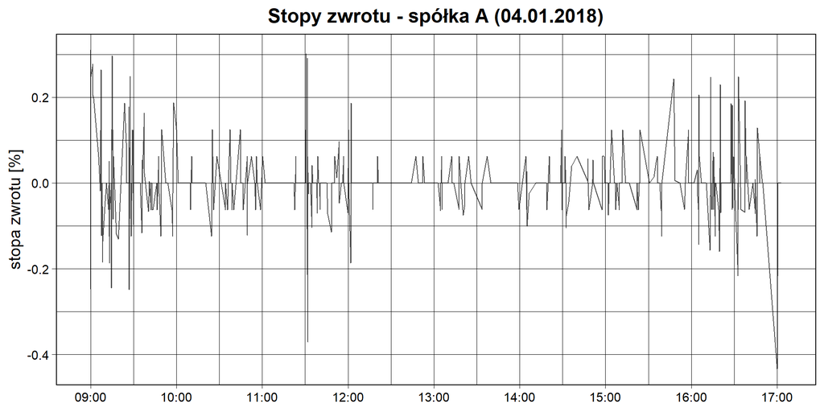

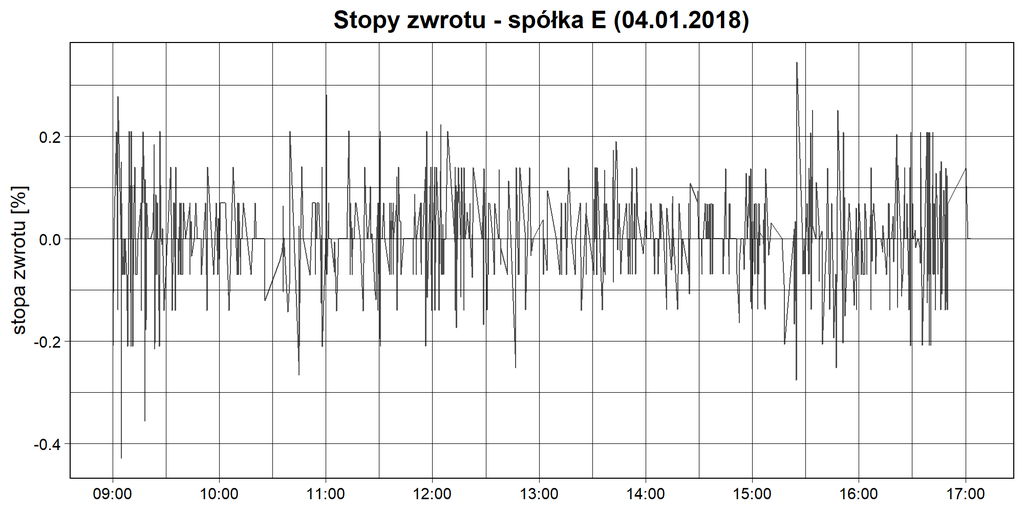

Statystyki opisowe stóp zwrotu

|  | Średnia | Odch. std. | Mediana | Min | Max | Skośność | Kurtoza |
| --- | --- | --- | --- | --- | --- | --- | --- |
| Spółka A | 0 | 0.113 | 0 | -8.781 | 6.705 | -0.837 | 163.801 |
| Spółka E | 0 | 0.123 | 0 | -7.671 | 9.275 | 0.881 | 179.923 |

Stopy zwrotu obu spółek są skupione wokół zera, przy porównywalnym poziomie zmienności, nieco wyższym dla spółki E. W obu przypadkach występuje bardzo duża liczba obserwacji skrajnych, co potwierdzają skrajnie wysokie wartości kurtozy. Rozkłady są nieznacznie asymetryczne, wyraźnie odbiegające od rozkładu normalnego, co jest zgodne z charakterem analizowanych danych.

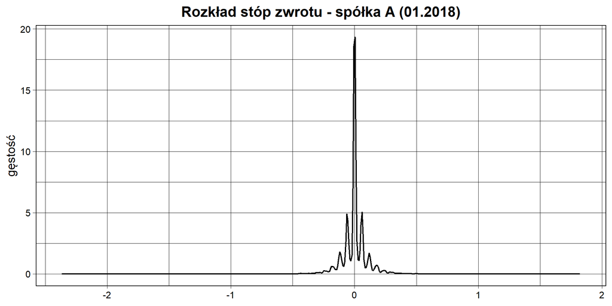

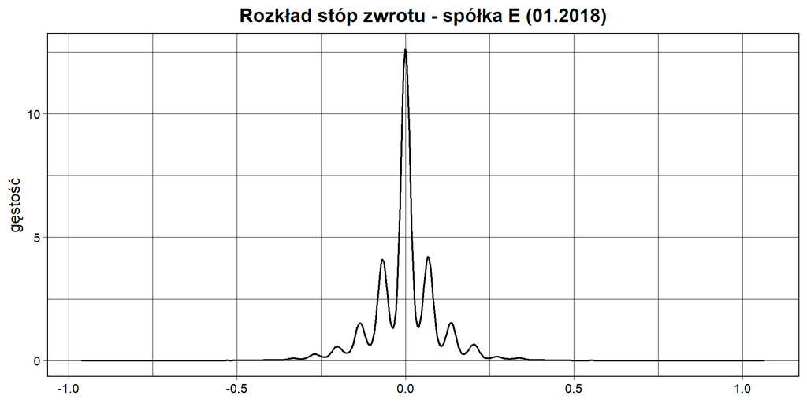

Wyniki testów normalności

| Spółka | Test | Statystyka | p-value |
| --- | --- | --- | --- |
| A | Andersona-Darlinga | 942.112 | < 2.2e-16 |
|  | Kolmogorova-Smirnova | 0.214 | < 2.2e-16 |
| E | Andersona-Darlinga | 365.754 | < 2.2e-16 |
|  | Kolmogorova-Smirnova | 0.196 | < 2.2e-16 |

Testy normalności Andersona-Darlinga oraz Kolmogorova-Smirnova wskazują na odrzucenie hipotezy zerowej dla obu spółek. Uzyskane wyniki testów, wraz z wcześniej wyznaczonymi statystykami opisowymi, potwierdzają brak normalności rozkładu analizowanych jednosekundowych stóp zwrotu.

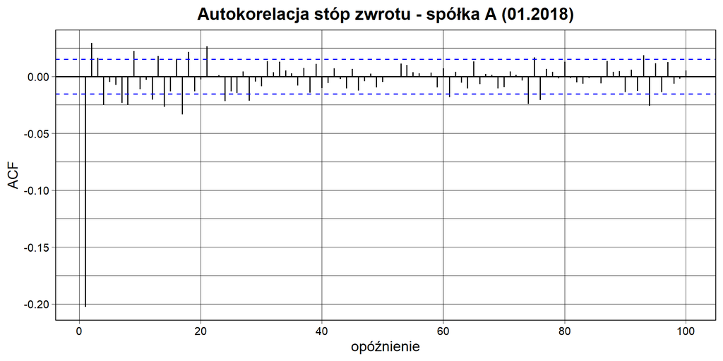

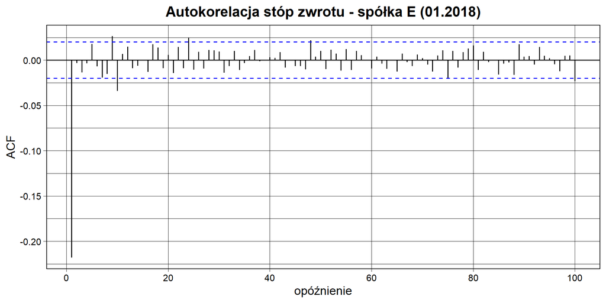

Autokorelacje jednosekundowych stóp zwrotu są w większości opóźnień nieistotne statystycznie. Dla obu spółek widoczna jest istotna ujemna autokorelacja pierwszego rzędu, natomiast dla dalszych opóźnień zależności są słabe i nieregularne. Wyniki wskazują na ograniczoną zależność jednosekundowych stóp zwrotu w czasie.

## Analiza danych 5-minutowych

### Przekrojowe średnie stóp zwrotu

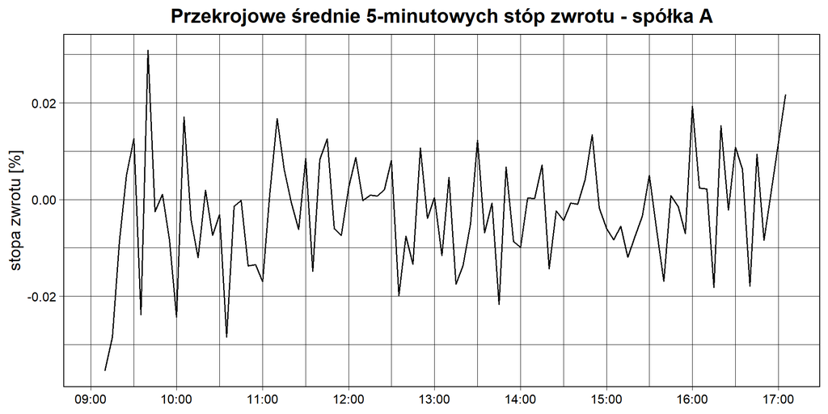

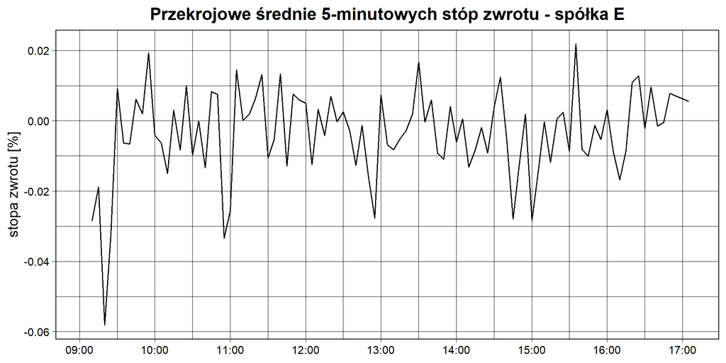

Przekrojowe średnie 5-minutowych stóp zwrotu dla obu spółek oscylują wokół zera w całym przebiegu sesji, bez trwałych wzorców czasowych. Obserwowane wahania mają charakter nieregularny i nie wskazują na systematyczne różnice pomiędzy poszczególnymi przedziałami czasowymi.

### Przekrojowe średnie liczby transakcji

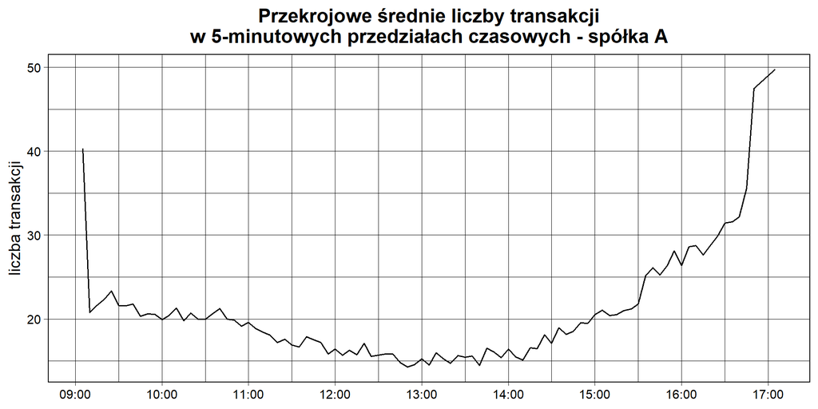

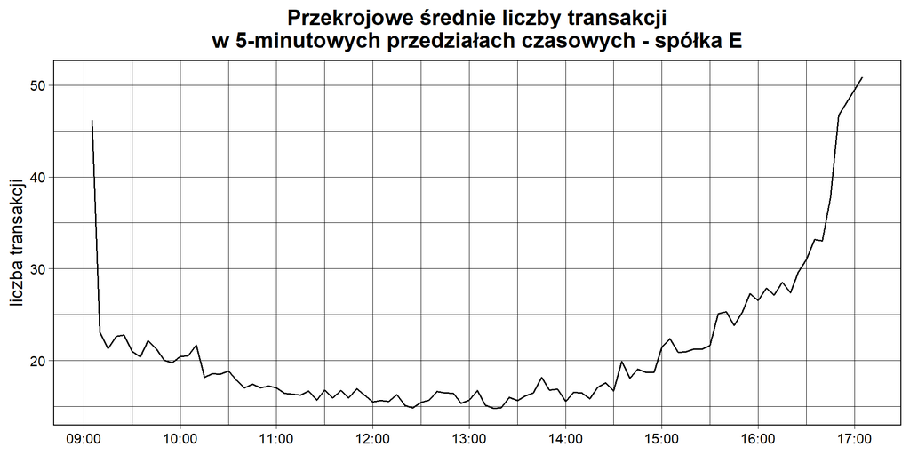

Dla obu spółek widoczny jest wyraźny U-kształtny przebieg liczby transakcji w trakcie sesji, z wysoką aktywnością na otwarciu i zamknięciu oraz obniżeniem intensywności handlu w trakcie dnia. Kształt profilu jest zbliżony dla obu spółek, co wskazuje na typowy śróddzienny charakter aktywności transakcyjnej.

### Przekrojowe średnie wolumenu

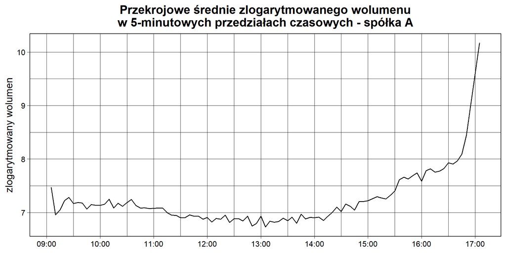

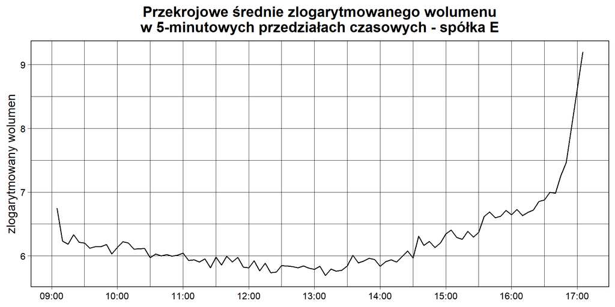

Przekrojowe średnie zlogarytmowanego wolumenu wykazują zależność od czasu trwania sesji, analogiczną do liczby transakcji. Najniższe poziomy wolumenu obserwowane są w środku dnia, natomiast istotny wzrost następuje w końcowej fazie sesji.

### Zmienność sezonowa

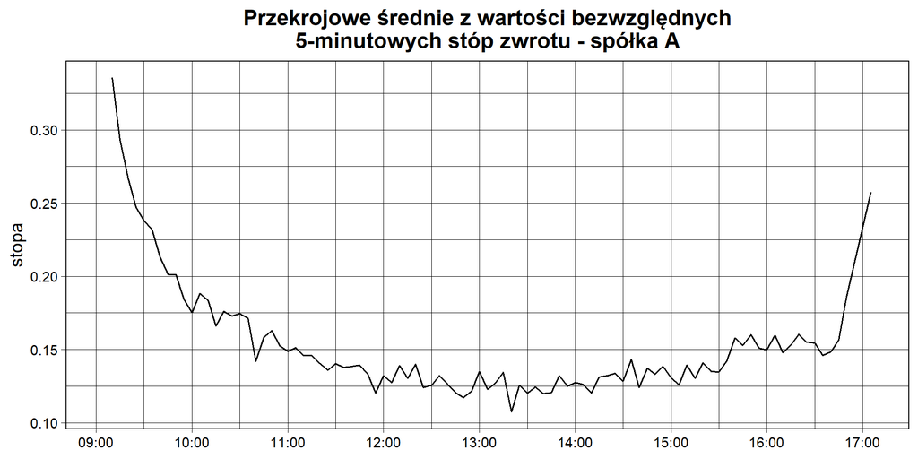

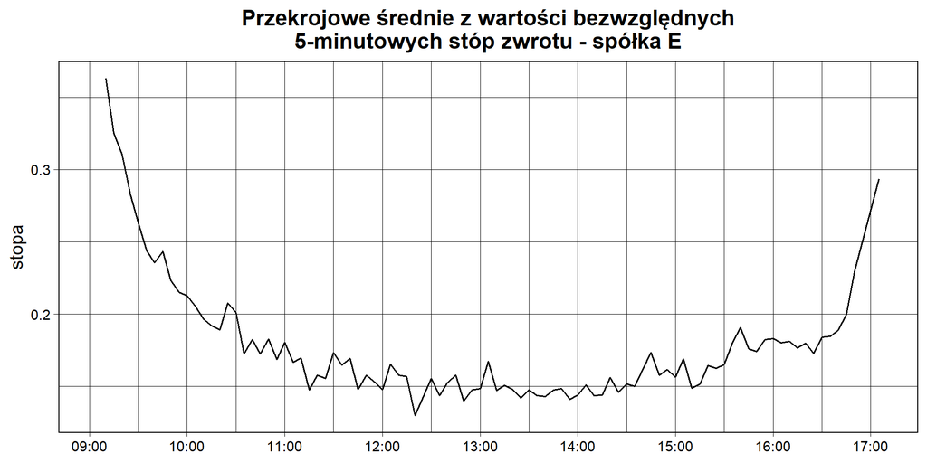

Przekrojowe średnie wartości bezwzględnych 5-minutowych stóp zwrotu wykazują wyraźny U-kształtny profil zmienności dla obu spółek. Zmienność jest najwyższa na otwarciu i zamknięciu sesji oraz najniższa w jej środkowej części, co potwierdza obecność silnej śróddziennej sezonowości zmienności.

## Modelowanie zmienności danych śróddziennych

### Elastyczna Forma Fouriera

Dla spółki A zastosowano metodę usuwania śróddziennej sezonowości zmienności opartą na Elastycznej Formie Fouriera. Analiza została przeprowadzona na 5-minutowych stopach zwrotu, przy czym jako estymator dziennej zmienności przyjęto wariancję dziennych stóp zwrotu obliczanych pomiędzy otwarciem a zamknięciem sesji giełdowej.  
Rząd rozwinięcia Fouriera dobrano na podstawie kryteriów informacyjnych. Kryterium AIC osiągało najmniejszą wartość dla P = 10, natomiast kryterium BIC dla P = 3. Aby uniknąć nadmiernego dopasowania śróddziennego profilu zmienności, w dalszej analizie ograniczono się do trzeciego rzędu Fouriera, zgodnie z kryterium BIC.  
Po ustaleniu rzędu Fouriera rozważono uwzględnienie zmiennych binarnych dla dni tygodnia. Porównanie modeli z i bez zmiennych binarnych przeprowadzono przy wykorzystaniu testu F, który nie wykazał istotnej poprawy (p-value = 0.43). Również wartości kryteriów informacyjnych nie wykazały znacznej różnicy pomiędzy modelami, w związku z czym w dalszej analizie wykorzystano model bez zmiennych binarnych.  
Na poniższych wykresach porównano przekrojowe średnie z modułów 5-minutowych stóp zwrotu oraz autokorelacje wartości bezwzględnych 5-minutowych stóp zwrotu przed i po usunięciu śróddziennej sezonowości. Dodatkowo przedstawiono wykres przeciętnych wartości składowej sezonowej zmienności w trakcie sesji.

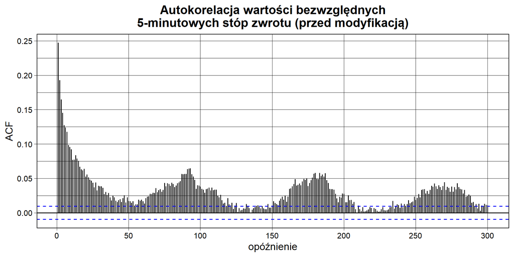

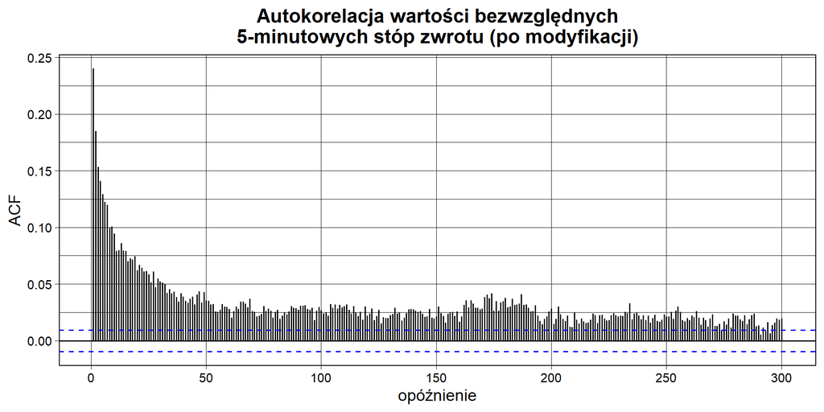

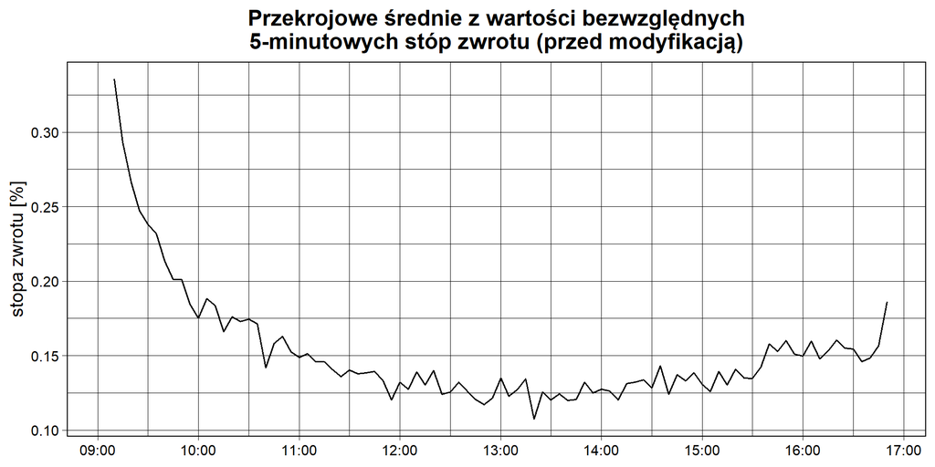

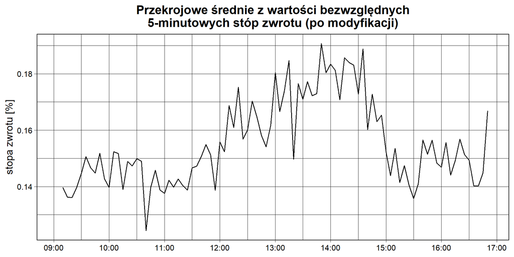

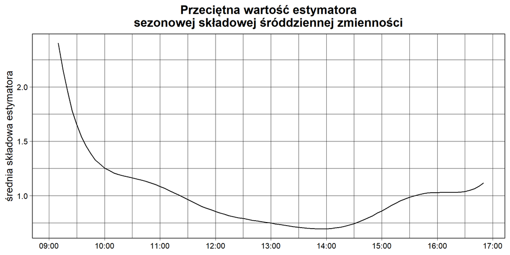

### Model multiplikatywny Engle i Sokalskiej

Dla spółki E zastosowano metodę usuwania śróddziennej sezonowości zmienności opartą na modelu multiplikatywnym Engle i Sokalskiej. Analiza została przeprowadzona na 5-minutowych stopach zwrotu, przy czym do estymacji dziennej zmienności wykorzystano model ARMA-GARCH dopasowany do dziennych stóp zwrotu obliczanych pomiędzy otwarciem a zamknięciem sesji giełdowej.  
Specyfikację modelu dobrano na podstawie kryteriów informacyjnych. Kryteria AIC oraz BIC osiągnęły najmniejsze wartości dla modelu ARMA(2,2)-GARCH(1,1), który został przyjęty jako ostateczny model opisujący dynamikę dziennej zmienności i wykorzystany w dalszej analizie.  
Na poniższych wykresach porównano przekrojowe średnie z modułów 5-minutowych stóp zwrotu oraz autokorelacje wartości bezwzględnych 5-minutowych stóp zwrotu przed i po usunięciu śróddziennej sezonowości. Dodatkowo przedstawiono wykres wartości składowej sezonowej zmienności w trakcie sesji.

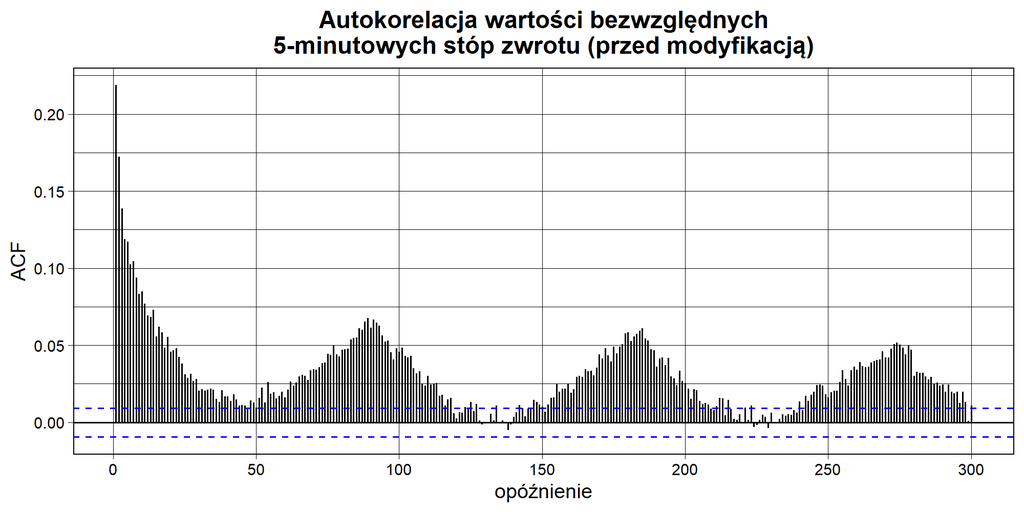

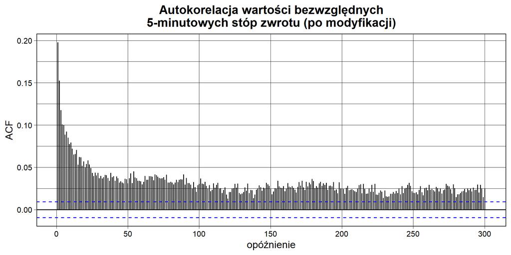

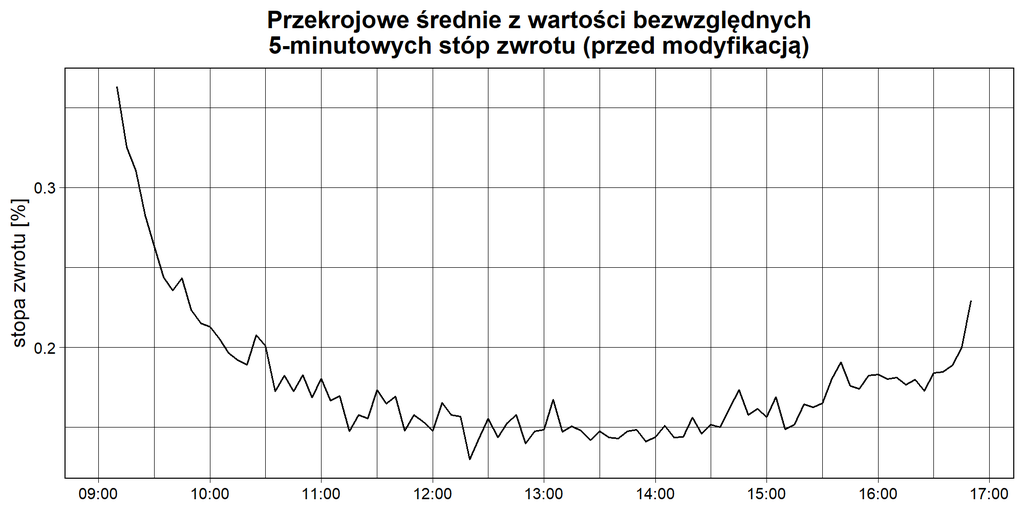

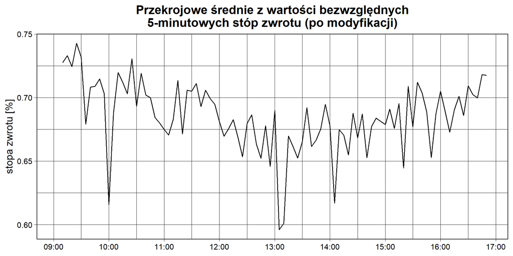

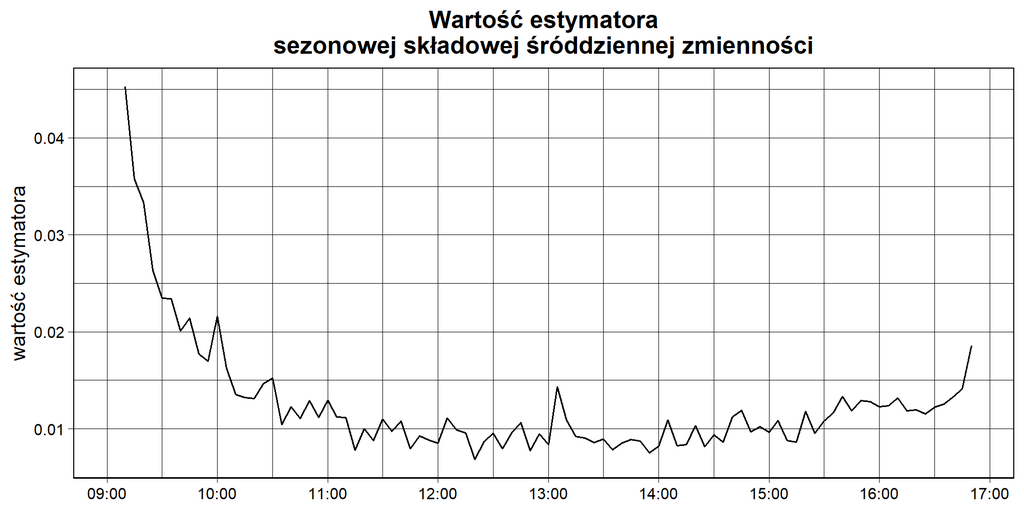

Zastosowanie multiplikatywnego modelu Engle i Sokalskiej umożliwiło usunięcie śróddziennej sezonowości zmienności dla spółki E. Przed modyfikacją obserwowana była wyraźna autokorelacja wartości bezwzględnych 5-minutowych stóp zwrotu oraz U-kształtny profil przekrojowych średnich zmienności. Po korekcie autokorelacje uległy osłabieniu, a przekrojowe średnie zostały wyraźnie spłaszczone. Oszacowana sezonowa składowa zmienności potwierdza podwyższoną zmienność na otwarciu i zamknięciu sesji oraz niższy poziom w jej środkowej części.